# Test on the first zip

### Combine Hourly and Plot

```r
# Combine
ucdavis_stat_data_hour_dry_bulb_temp_3_cols <- hourly_3_cols(ucdavis_stat_data_hour_dry_bulb_temp)
head(ucdavis_stat_data_hour_dry_bulb_temp_3_cols)
```

```
##   col c(0:23) col_names
## 1 8.1       0         1
## 2 7.7       1         1
## 3 7.6       2         1
## 4 7.3       3         1
## 5 7.3       4         1
## 6 7.2       5         1
```

```r
ucdavis_stat_data_hour_dew_point_temp_3_cols <- hourly_3_cols(ucdavis_stat_data_hour_dew_point_temp)
head(ucdavis_stat_data_hour_dew_point_temp_3_cols)
```

```
##   col c(0:23) col_names
## 1 6.3       0         1
## 2 6.0       1         1
## 3 5.9       2         1
## 4 5.7       3         1
## 5 5.6       4         1
## 6 5.6       5         1
```

```r
ucdavis_stat_data_hour_relative_humid_3_cols <- hourly_3_cols(ucdavis_stat_data_hour_relative_humid)
head(ucdavis_stat_data_hour_relative_humid_3_cols)
```

```
##   col c(0:23) col_names
## 1  89       0         1
## 2  90       1         1
## 3  89       2         1
## 4  91       3         1
## 5  90       4         1
## 6  91       5         1
```

```r
ucdavis_stat_data_hour_dircect_NSR_3_cols <- hourly_3_cols(ucdavis_stat_data_hour_relative_humid)
head(ucdavis_stat_data_hour_dircect_NSR_3_cols)
```

```
##   col c(0:23) col_names
## 1  89       0         1
## 2  90       1         1
## 3  89       2         1
## 4  91       3         1
## 5  90       4         1
## 6  91       5         1
```

```r
ucdavis_stat_data_hour_wind_speed_3_col <- hourly_3_cols(ucdavis_stat_data_hour_wind_speed)
head(ucdavis_stat_data_hour_wind_speed_3_col)
```

```
##   col c(0:23) col_names
## 1  89       0         1
## 2  90       1         1
## 3  89       2         1
## 4  91       3         1
## 5  90       4         1
## 6  91       5         1
```

```r
ucdavis_hour_combined_df <- combine_hour(ucdavis_stat_data_hour_dry_bulb_temp_3_cols,ucdavis_stat_data_hour_dew_point_temp_3_cols,ucdavis_stat_data_hour_relative_humid_3_cols,ucdavis_stat_data_hour_dircect_NSR_3_cols,ucdavis_stat_data_hour_wind_speed_3_col)
head(ucdavis_hour_combined_df)
```

```
##   Hour Month Dry Bulb temperatures Dew Point temperatures Relative Humidity
## 1    0     1                   8.1                    6.3                89
## 2    1     1                   7.7                    6.0                90
## 3    2     1                   7.6                    5.9                89
## 4    3     1                   7.3                    5.7                91
## 5    4     1                   7.3                    5.6                90
## 6    5     1                   7.2                    5.6                91
##   Direct Normal Solar Radiation Wind Speed
## 1                            89         89
## 2                            90         90
## 3                            89         89
## 4                            91         91
## 5                            90         90
## 6                            91         91
```

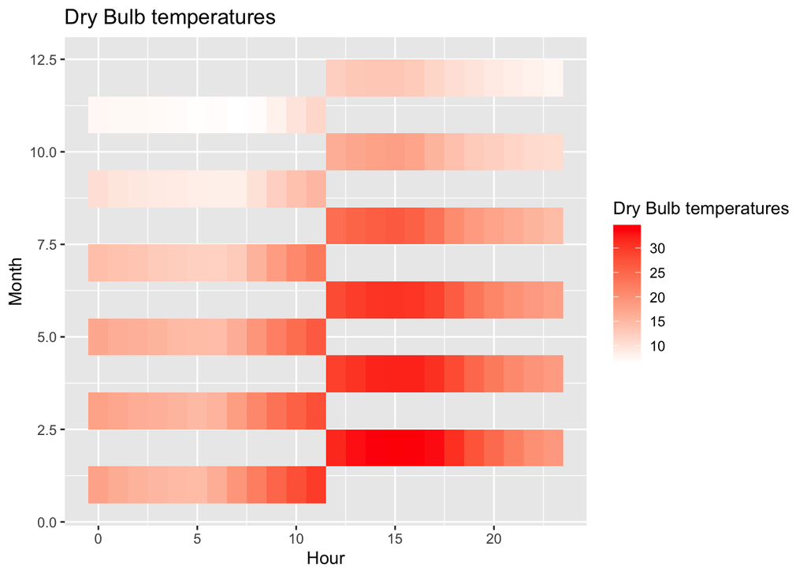

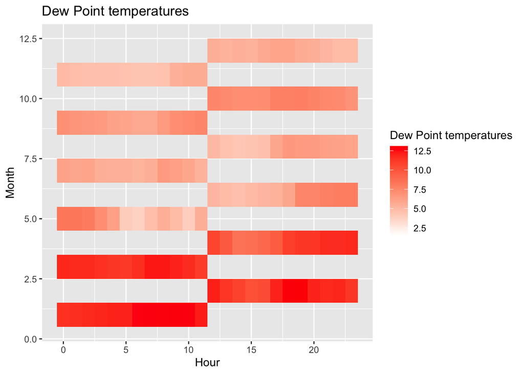

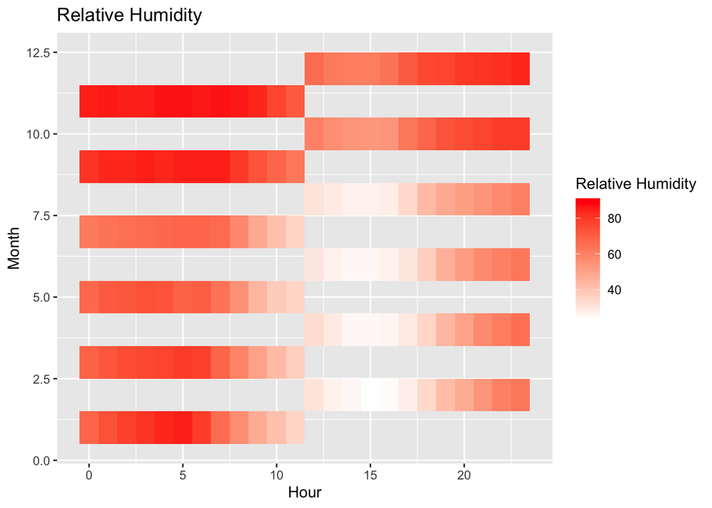

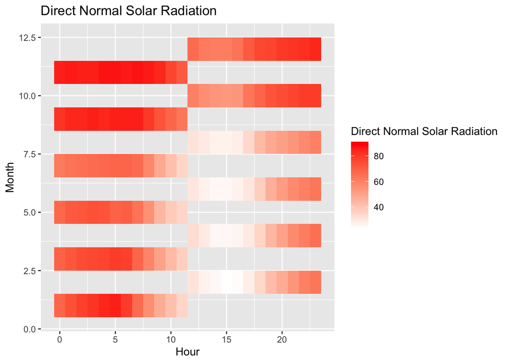

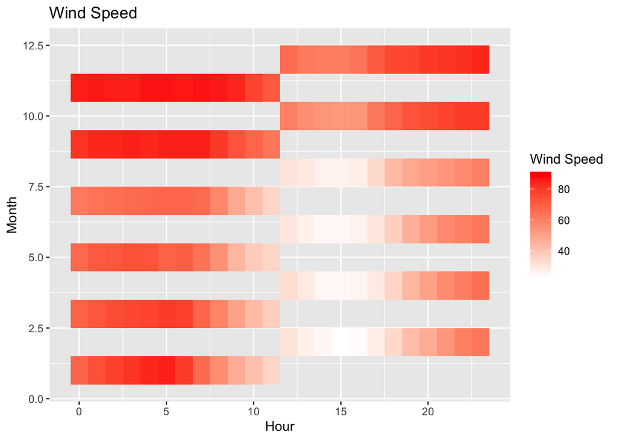

```r
#Plot
plot_hourly_df(ucdavis_hour_combined_df)
```

# Verification

## Monthly Data

Below is a test conducted by randomly selecting dataframs, and using the function below to print their min and max, in order to check the consistency between lines and df. During the test, I found out the min for monthly wind speed contains lots of 0s, at first I suspect its corectness, then I went back to each df initialization, and found out that it’s normal to have wind speed as 0.

```r
my_which_min_max <- function(tdata){
  if(!"Maximum " %in% colnames(tdata) | !"Minimum " %in% colnames(tdata)){
    warning("Unfitted data!")
    stop("No maximum or minimum col in the df!")
    return(tdata)
  }
  print(tdata[which(tdata$`Maximum ` == max(tdata$`Maximum `))[1],])
  print(tdata[which(tdata$`Minimum ` == min(tdata$`Minimum `))[1],])
}



statlines <- c(sf_statlines, marin_statlines, napa_statlines, point_statlines, ucdavis_statlines)
statlines[grep("Maximum Dry Bulb temperature", statlines)]
```

```
## [1] "   - Maximum Dry Bulb temperature of  37.8C on Jun  8"
## [2] "   - Maximum Dry Bulb temperature of  37.0C on Jun  4"
## [3] "   - Maximum Dry Bulb temperature of  35.6C on Jun 17"
## [4] "   - Maximum Dry Bulb temperature of  26.7C on Apr 30"
## [5] "   - Maximum Dry Bulb temperature of  42.0C on Jul  7"
```

```r
statlines[grep("Minimum Dry Bulb temperature", statlines)]
```

```
## [1] "   - Minimum Dry Bulb temperature of  -0.8C on Jan  2"
## [2] "   - Minimum Dry Bulb temperature of  -3.0C on Dec 19"
## [3] "   - Minimum Dry Bulb temperature of  -3.3C on Feb 27"
## [4] "   - Minimum Dry Bulb temperature of   4.8C on Feb 27"
## [5] "   - Minimum Dry Bulb temperature of  -1.0C on Jan  2"
```

```r
statlines[grep("Maximum Wind Speed", statlines)]
```

```
## [1] "   - Maximum Wind Speed of  12.4 m/s on Dec 31"
## [2] "   - Maximum Wind Speed of  12.4 m/s on Jan 18"
## [3] "   - Maximum Wind Speed of  17.0 m/s on Oct  7"
## [4] "   - Maximum Wind Speed of  18.5 m/s on May 21"
## [5] "   - Maximum Wind Speed of  14.4 m/s on Jan  6"
```

```r
statlines[grep("Minimum Wind Speed", statlines)]
```

```
## [1] "   - Minimum Wind Speed of   0.0 m/s on Jan  2"
## [2] "   - Minimum Wind Speed of   0.0 m/s on Jan  1"
## [3] "   - Minimum Wind Speed of   0.0 m/s on Jan  1"
## [4] "   - Minimum Wind Speed of   0.0 m/s on Jan  1"
## [5] "   - Minimum Wind Speed of   0.0 m/s on Jan  1"
```

```r
my_which_min_max(sf_stat_data_month_dry_bulb_temp_t)
```

```
##     Maximum             Day:Hour Minimum             Day:Hour Daily Avg
## Jun     37.8 2023-06-08 17:00:00     11.6 2023-06-19 06:00:00      19.8
##     Daily Range DayTime Max DayTime Min DayTime Avg NightTime Max NightTime Min
## Jun        13.6        37.8        12.7        22.5          34.6          11.6
##     NightTime Avg
## Jun          17.1
##     Maximum             Day:Hour Minimum             Day:Hour Daily Avg
## Jan     24.4 2023-01-31 16:00:00     -0.8 2023-01-02 07:00:00       9.4
##     Daily Range DayTime Max DayTime Min DayTime Avg NightTime Max NightTime Min
## Jan         9.5        24.4        -0.8        10.6          17.8          -0.3
##     NightTime Avg
## Jan           8.2
```

```r
my_which_min_max(sf_stat_data_month_dew_point_temp_t)
```

```
##     Maximum             Day:Hour Minimum             Day:Hour Daily Avg
## Aug     18.3 2023-08-15 20:00:00        8 2023-08-21 18:00:00      12.8
##     Maximum             Day:Hour Minimum    Day:Hour Daily Avg
## Dec     12.3 2023-12-24 16:00:00    -11.2 2024-01-01       4.6
```

```r
my_which_min_max(sf_stat_data_month_wind_speed_t)
```

```
##     Maximum            Day:Hour  Minimum            Day:Hour  Daily Avg
## Dec     12.4 2023-12-31 07:00:00        0 2023-12-02 07:00:00       2.5
##     Maximum            Day:Hour  Minimum            Day:Hour  Daily Avg
## Jan      6.7 2023-01-31 13:00:00        0 2023-01-02 09:00:00       1.8
```

```r
my_which_min_max(point_stat_data_month_wind_speed_t)
```

```
##     Maximum   Day:Hour  Minimum            Day:Hour  Daily Avg
## May     18.5 2023-05-22        0 2023-05-01 09:00:00       7.7
##     Maximum            Day:Hour  Minimum            Day:Hour  Daily Avg
## Jan     16.5 2023-01-15 20:00:00        0 2023-01-01 15:00:00       4.4
```

```r
point_stat_data_month_wind_speed_t
```

```
##     Maximum            Day:Hour  Minimum            Day:Hour  Daily Avg
## Jan     16.5 2023-01-15 20:00:00        0 2023-01-01 15:00:00       4.4
## Feb     16.4 2023-02-13 13:00:00        0 2023-02-02 19:00:00       6.2
## Mar     14.4 2023-03-07 19:00:00        0 2023-03-02 10:00:00       4.9
## Apr     14.9 2023-04-17 09:00:00        0 2023-04-07 10:00:00       5.2
## May     18.5 2023-05-22 00:00:00        0 2023-05-01 09:00:00       7.7
## Jun     14.9 2023-06-03 19:00:00        0 2023-06-02 23:00:00       5.2
## Jul     13.9 2023-07-07 06:00:00        0 2023-07-01 17:00:00       4.8
## Aug     15.4 2023-08-09 16:00:00        0 2023-08-01 17:00:00       3.2
## Sep     13.9 2023-09-04 14:00:00        0 2023-09-01 08:00:00       5.0
## Oct     13.9 2023-10-21 02:00:00        0 2023-10-01 23:00:00       4.1
## Nov     15.9 2023-11-29 09:00:00        0 2023-11-02 09:00:00       4.3
## Dec     13.9 2023-12-19 16:00:00        0 2023-12-04 03:00:00       4.9
```

# Assumption and Conclusion

My workflow for this project can be divided into the following steps:

1. Focus on the first zip file to look for the pattern within it.
   - Read wea and pvsyst file since their simplicity.
     - Assuming each wea and pvsyst has same skip lines. Turns out they do.
   - Read Stat file
     - Resolved Difficulty:
       - Encoding issue solved by explicitly claim that locale = locale(encoding = “ISO-8859-1”)
       - Choosing the end pattern: changing “[C]” to “-” since the pattern is that each information is fully displayed right after the next “-”
       - Convert the column Day:Hour into time variables using the combination of paste0 and as.POSIXct. And it’s important to match the final string with the format.
       - In my convert to numeric function, it’s important to convert only char into double instead of posixct, otherwise the posixct elements will end up with wrong values.
2. Apply functions to the rest files
   - When applying functions, I notice that it’s worthy to add a if condition that recognizes the input value is the one we want to manipulate. Otherwise it will potentially change the data.
   - I assign distinct variables name to each df instead of overwriting them since I think it’s easy to debug and double check. For example, if one dataframe is wrong, I can locate it fast and easily.
   - But assigning the variables names can be overwhelming, so I just search them and replace the words partially.